# Exploring & Modeling MA Public School District Data

### Big Districts

The dashed blue line in the boxplot above represents the mean state college attendance rate for all students. This is a cumulative mean, meaning that it is calculated by dividing the total number of students attending college by the total number of senior students in the state. The calculated means for each group are a “mean of means” and are calculated by averaging the mean college attendance rate for each district and specific racial / low income group. These calculations are inherently biased since we showed that the enrollment histogram does not follow a normal distribution. Smaller districts are therefore disproportinately represented in these calculated means, so we must determine whether grade 12 enrollment size plays a role in college attendance rates.

```r
data$DistSize <- "Normal"
for (i in 1:nrow(data)){
  if ((data$G12[i] >= 500) == TRUE){
    data$DistSize[i] <- "Big"
  }
}
count=0
for (x in data$DistSize){
  if (x=="Big"){
    count = count +1
  }
}
count
```

```
## [1] 15
```

```r
nrow(data)-count
```

```
## [1] 253
```

We have defined large districts as having at least 500 12th grade students enrolled. The dataset has 15 large districts, and 253 “normal” sized districts.

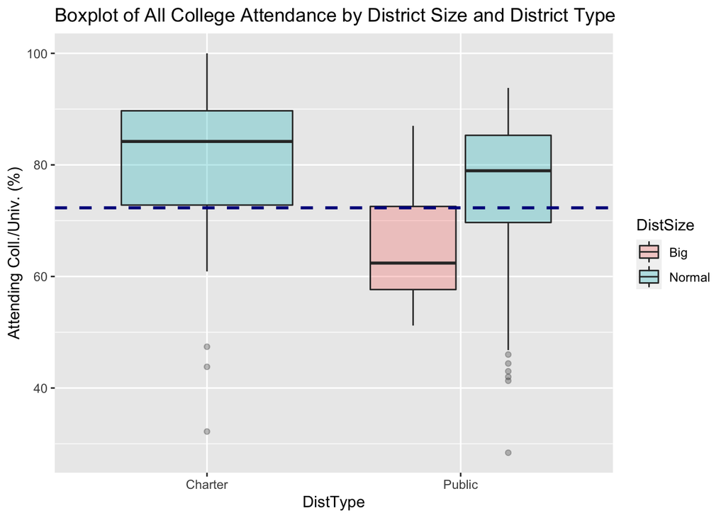

```r
allcollboxplot <- ggplot(data, aes(x=DistType, y=`Attending Coll./Univ. (%)`, fill=DistSize)) +
  geom_boxplot(alpha=0.3) +
  ggtitle("Boxplot of All College Attendance by District Size and District Type") +
  geom_hline(aes(yintercept=statetotals$Attending.Coll..Univ......1),color="darkblue", linetype="dashed", size=1)
allcollboxplot
```

The boxplot above suggests that there is a large difference in the overall college attendance rates between large districts and normal districts. Additionally, it shows that there are no charter districts classified as “large”, and the overall college attendance rate is only slightly larger (~5%) for charter districts compared to non-charter districts.

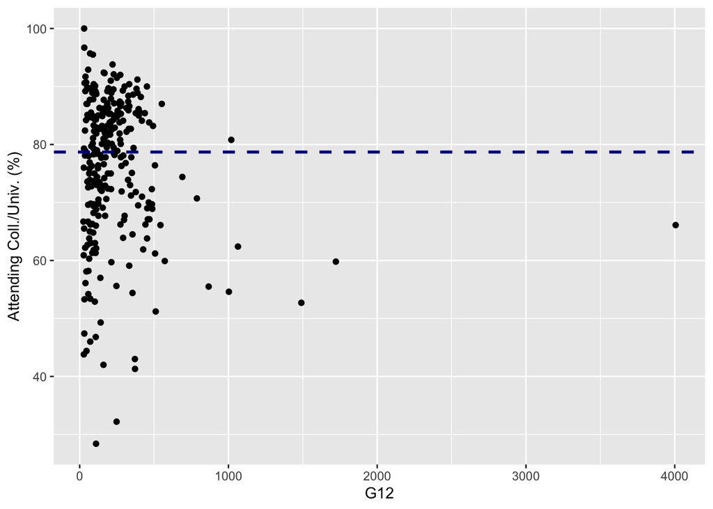

```r
ggplot(data, aes(x=G12, y=`Attending Coll./Univ. (%)`)) + geom_point() + geom_hline(aes(yintercept=median(`Attending Coll./Univ. (%)`)),color="darkblue", linetype="dashed", size=1)
```

We can also visualize the relationship between grade 12 enrollment and college attendance rates using the scatterplot above. We can see that many of the schools with higher grade 12 enrollment have college attendance rates that fall well below the median. As grade 12 enrollment decreases, the mean college attendance rates per district are more evenly distributed about the median.

It is worth noting that since a large number of the state’s students come from these larger districts, in the future it is worth analyzing these districts in more detail independent from the other districts.

### College Attendance in Big Districts

```r
bigdist <- data %>% filter(DistSize != "Normal")
```

[figure not shown]

```r
data <- data %>% filter(DistType != "Charter")
```

## Multivariate Regression

### Subsetting Data

We will start by subsetting the dataframe with our chosen potential predictor variables. There are 14 variables that I have selected that aim to quantify size, salaries and funding, percent enrollment of selected populations, achievement indicators, as well as teacher performance. The variables and their descriptive statistics are below.

```r
collegeattendvars <- data.frame(data$`District Name`, data$G12, data$`Average Class Size`, data$enroll_hispanic, data$enroll_low_econ, data$`Actual NSS as % of Required`, data$`Average Salary`, data$`Total Expenditures per Pupil`, data$reading_writing_all, data$math_all, data$`% All Completed Advanced`, data$`% Exemplary`,data$`% Proficient`, data$`% Needs Improvement`, data$`Attending Coll./Univ. (%)`)
collegeattendvars <- collegeattendvars %>% filter_all(all_vars(.!= 99999))
columns <- c('name', 'g12', 'class_size', 'enroll_hisp', 'enroll_lowincome','actualNSS', 'avg_salary', 'per_pupil', 'sat_rr', 'sat_math', 'advanced_course', 'exemplary', 'proficient', 'needs_improv', 'college')
names(collegeattendvars) <- columns
summarytools::descr(collegeattendvars[2:15])
```

```
## Descriptive Statistics
## collegeattendvars
## N: 224
##
##                     actualNSS   advanced_course   avg_salary   class_size   college   enroll_hisp
## ----------------- ----------- ----------------- ------------ ------------ --------- -------------
##              Mean      129.39             67.40     77573.43        17.74     75.73         11.23
##           Std.Dev       24.39             16.27      8682.29         1.95     11.64         14.65
##               Min       97.00             19.00     59813.00        11.80     28.40          0.30
##                Q1      110.00             57.20     71496.00        16.60     68.85          3.95
##            Median      126.00             65.15     76959.50        18.05     78.15          5.90
##                Q3      141.00             78.50     82610.50        19.05     85.05         11.15
##               Max      233.00            100.00    102630.00        22.30     93.80         92.90
##               MAD       22.98             14.75      8172.09         1.70     11.42          4.00
##               IQR       31.00             21.20     11104.25         2.42     16.15          7.15
##                CV        0.19              0.24         0.11         0.11      0.15          1.30
##          Skewness        1.27              0.18         0.52        -0.54     -0.89          2.98
##       SE.Skewness        0.16              0.16         0.16         0.16      0.16          0.16
##          Kurtosis        2.23             -0.31         0.35         0.23      0.65          9.95
##           N.Valid      224.00            224.00       224.00       224.00    224.00        224.00
##         Pct.Valid      100.00            100.00       100.00       100.00    100.00        100.00
##
## Table: Table continues below
##
##
##
##                     enroll_lowincome   exemplary       g12   needs_improv   per_pupil   proficient
## ----------------- ------------------ ----------- --------- -------------- ----------- ------------
##              Mean            1208.74       14.19    268.57           2.82    15708.71        82.73
##           Std.Dev            2937.22        9.23    329.03           2.87     2650.48         9.37
##               Min              51.00        0.00     29.00           0.00    11598.88        54.90
##                Q1             255.00        7.70    116.50           1.10    13966.46        77.75
##            Median             451.50       12.65    203.50           1.85    15138.24        83.80
##                Q3             838.00       18.90    329.00           3.65    16735.23        89.45
##               Max           30720.00       44.70   4006.00          19.30    30443.42        98.60
##               MAD             358.79        7.71    140.85           1.48     2018.03         8.75
##               IQR             579.00       11.15    211.75           2.52     2765.30        11.65
##                CV               2.43        0.65      1.23           1.02        0.17         0.11
##          Skewness               6.54        1.01      7.35           2.53        1.90        -0.74
##       SE.Skewness               0.16        0.16      0.16           0.16        0.16         0.16
```

[output cut: 10 more lines]

```
##              Mean     559.47   560.78
##           Std.Dev      39.35    34.61
##               Min     427.00   431.00
##                Q1     537.50   544.50
##            Median     556.50   560.00
##                Q3     581.00   580.00
##               Max     684.00   656.00
##               MAD      30.39    27.43
##               IQR      42.75    35.25
##                CV       0.07     0.06
##          Skewness       0.08    -0.40
##       SE.Skewness       0.16     0.16
##          Kurtosis       0.85     0.93
##           N.Valid     224.00   224.00
##         Pct.Valid     100.00   100.00
```

### Correlation Matrix

Now let’s create a correlation matrix to determine which variables have high collinearity so that we can be more efficient when choosing our regression variables.

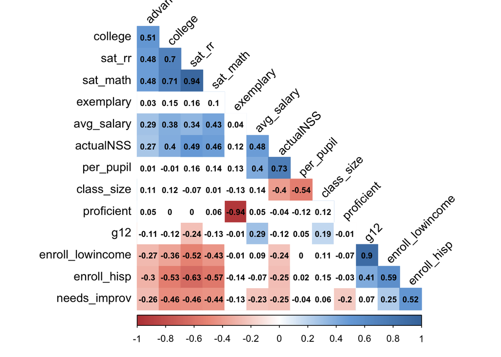

```r
res <- rcorr(as.matrix(collegeattendvars[2:15]), type = "pearson")
col <- colorRampPalette(c("#BB4444", "#EE9988", "#FFFFFF", "#77AADD", "#4477AA"))
corrplot(res$r, method = "color", col = col(200),
         type = "lower", order = "hclust", number.cex = .7,
         addCoef.col = "black", # Add coefficient of correlation
         tl.col = "black", tl.srt = 45, # Text label color and rotation
         # Combine with significance
         p.mat = res$P, sig.level = 0.01, insig = "blank",
         # hide correlation coefficient on the principal diagonal
         diag = FALSE)
```

Looking at the correlation matrix, there are many variables which are significantly correlated with college attendance rates (`advanced courses`, `sat reading and writing`, `sat math`, `average teacher salary`, `net school spending relative to required spending`, `percent of teachers needing improvement`, `hispanic/latinx enrollment`, and `low income enrollment`). The two SAT score variables are very highly correlated, so we will only use one in the regression model (`sat math`). There is some minor collinearity between some of the other variables, but we will run the regression model with them and then re-evaluate.

### Modeling

```r
fitall <- lm(college ~ sat_math + avg_salary + per_pupil + advanced_course + needs_improv + actualNSS + enroll_lowincome + enroll_hisp, data=collegeattendvars)
summary(fitall)
```

```
##
## Call:
## lm(formula = college ~ sat_math + avg_salary + per_pupil + advanced_course +
##     needs_improv + actualNSS + enroll_lowincome + enroll_hisp,
##     data = collegeattendvars)
##
## Residuals:
##     Min      1Q  Median      3Q     Max
## -21.270  -3.906   1.101   4.465  18.260
##
## Coefficients:
##                    Estimate Std. Error t value Pr(>|t|)
## (Intercept)       1.181e+00  9.315e+00   0.127  0.89924
## sat_math          1.064e-01  1.871e-02   5.690 4.14e-08 ***
## avg_salary        1.875e-04  7.288e-05   2.573  0.01075 *
## per_pupil        -1.582e-03  2.951e-04  -5.360 2.14e-07 ***
## advanced_course   1.060e-01  3.462e-02   3.061  0.00248 **
## needs_improv     -4.163e-01  2.039e-01  -2.042  0.04236 *
## actualNSS         1.583e-01  3.550e-02   4.459 1.33e-05 ***
## enroll_lowincome  6.794e-08  2.172e-04   0.000  0.99975
## enroll_hisp      -1.023e-01  4.917e-02  -2.081  0.03864 *
## ---
## Signif. codes:  0 '***' 0.001 '**' 0.01 '*' 0.05 '.' 0.1 ' ' 1
##
## Residual standard error: 7.16 on 215 degrees of freedom
## Multiple R-squared:  0.6353, Adjusted R-squared:  0.6217
## F-statistic: 46.81 on 8 and 215 DF,  p-value: < 2.2e-16
```

```r
Anova(fitall)
```

|  | Sum Sq | Df | F value | Pr(>F) |
| --- | --- | --- | --- | --- |
| sat_math | 1.659560e+03 | 1 | 3.237131e+01 | 4.135067e-08 |
| avg_salary | 3.394753e+02 | 1 | 6.621793e+00 | 1.074654e-02 |
| per_pupil | 1.472732e+03 | 1 | 2.872705e+01 | 2.141072e-07 |
| advanced_course | 4.804620e+02 | 1 | 9.371873e+00 | 2.484289e-03 |
| needs_improv | 2.137967e+02 | 1 | 4.170310e+00 | 4.235900e-02 |
| actualNSS | 1.019271e+03 | 1 | 1.988187e+01 | 1.326677e-05 |
| enroll_lowincome | 5.015378e-06 | 1 | 9.782976e-08 | 9.997507e-01 |
| enroll_hisp | 2.219615e+02 | 1 | 4.329572e+00 | 3.864025e-02 |
| Residuals | 1.102227e+04 | 215 | NA | NA |

We can use modified hypothesis testing to determine whether a variable is contributing to the model. I will remove variables based on a p-value of <0.01. Based on the results above, we can see that `needs_improv`, `enroll_lowincome`, `avg_salary`, and `enroll_hisp` are not heavily contributing to the model. We can remove these variables and refit the regression model.

```r
fitnew <- lm(college ~ sat_math + per_pupil + advanced_course + actualNSS, data=collegeattendvars)
summary(fitnew)
```

```
##
## Call:
## lm(formula = college ~ sat_math + per_pupil + advanced_course +
##     actualNSS, data = collegeattendvars)
##
## Residuals:
##      Min       1Q   Median       3Q      Max
## -19.7703  -4.7063   0.9628   5.2115  18.8989
##
## Coefficients:
##                   Estimate Std. Error t value Pr(>|t|)
## (Intercept)     -1.442e+01  8.115e+00  -1.777 0.076920 .
## sat_math         1.485e-01  1.607e-02   9.238  < 2e-16 ***
## per_pupil       -1.596e-03  2.961e-04  -5.389 1.83e-07 ***
## advanced_course  1.228e-01  3.540e-02   3.470 0.000627 ***
## actualNSS        1.845e-01  3.588e-02   5.142 6.02e-07 ***
## ---
## Signif. codes:  0 '***' 0.001 '**' 0.01 '*' 0.05 '.' 0.1 ' ' 1
##
## Residual standard error: 7.425 on 219 degrees of freedom
## Multiple R-squared:  0.6005, Adjusted R-squared:  0.5932
## F-statistic:  82.3 on 4 and 219 DF,  p-value: < 2.2e-16
```

```r
Anova(fitnew)
```

|  | Sum Sq | Df | F value | Pr(>F) |
| --- | --- | --- | --- | --- |
| sat_math | 4704.9501 | 1 | 85.34856 | 2.248453e-17 |
| per_pupil | 1600.9100 | 1 | 29.04077 | 1.826407e-07 |
| advanced_course | 663.6817 | 1 | 12.03929 | 6.272181e-04 |
| actualNSS | 1457.4872 | 1 | 26.43905 | 6.023958e-07 |
| Residuals | 12072.6598 | 219 | NA | NA |

The hypothesis tests show that all variables are significant. Now lets take a look at the diagnostic plots.

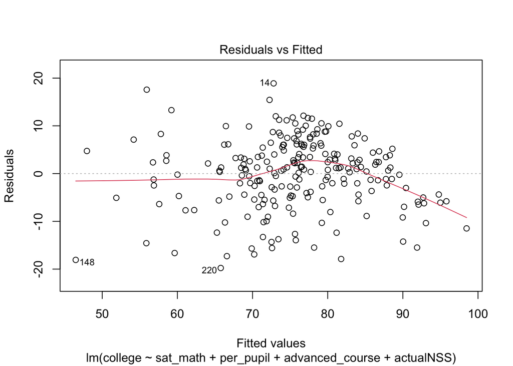

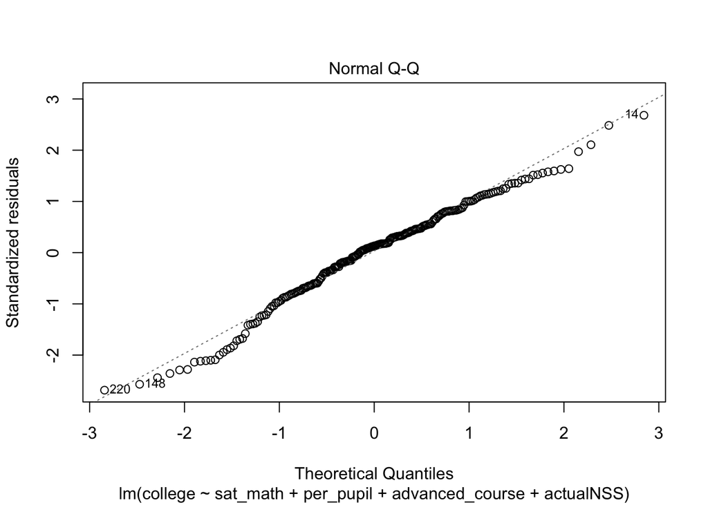

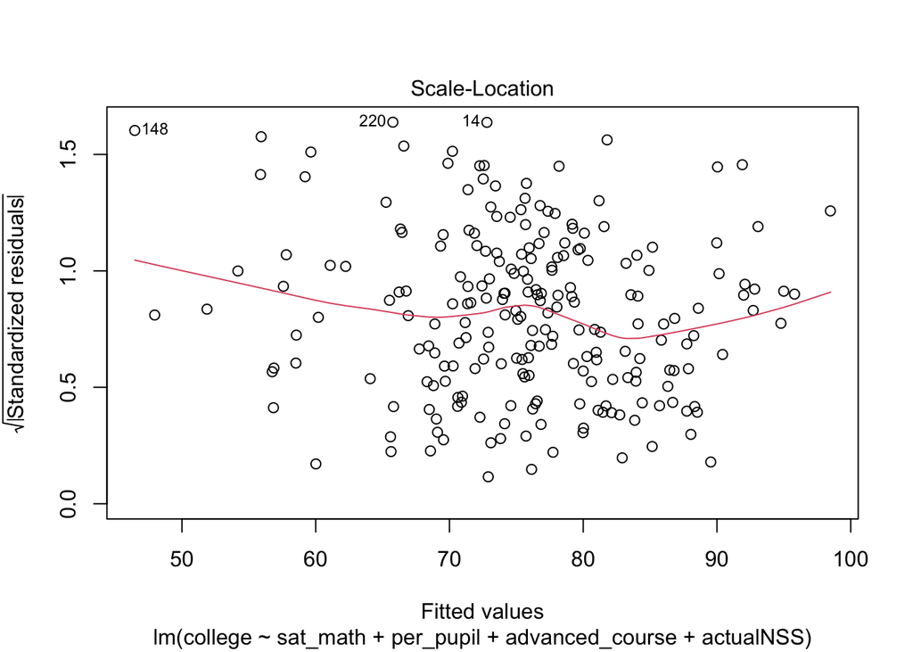

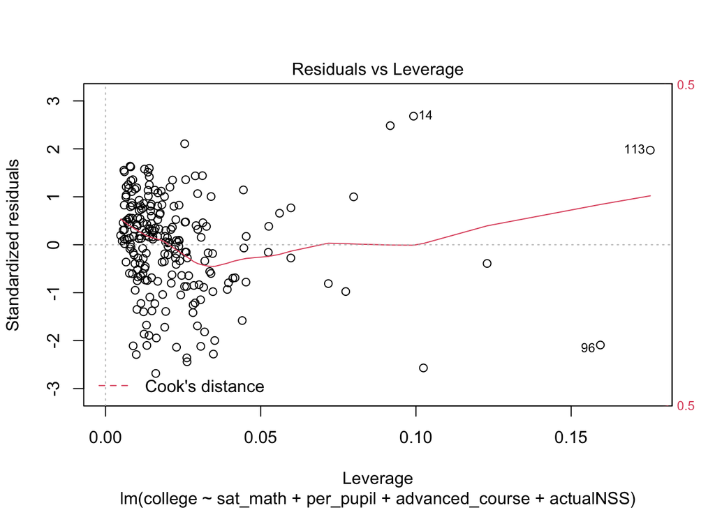

```r
plot(fitnew)
```